# Análisis exploratorio de datos de pedodiversidad

Carlos Manuel Guío Blanco

En este cuaderno se presenta un análisis de patrones de puntos de pedodiversidad.

## 1. Configuración

A continuación se cargan las librería necesarias

## 2. Carga de datos

Los datos producto del procesamiento, se han subido a un repositorio de Zenodo.

```r
#ruta_ucs_rao <- here::here("Data", "OUTPUT_rao_piloto_sf.qs")
#ucs_rao_sf <- qs::qread(ruta_ucs_rao) #lectura local

# Corre script externo
source(here::here("Scripts", "carga_ucs_procesadas_qs.R"), encoding = "UTF-8")

head(ucs_rao_sf)
```

[output not shown]

## 3. Análisis descriptivo

Se realiza análisis descriptivo para:

- Comprender la distribución de los datos
- Identificar la relación con las áreas de unidades cartográficas, para definir necesidades de normalización, derivación de nuevas variables (e.g. residuales) y metodologías de análisis de patrones de puntos.
- Identificar relaciones potenciales con otras variables.

### 3.1 Distribución de la diversidad (Q), del área (A) y su relación

Se inicia por un resumen estadístico general:

```r
#Se crea una variable Qdens que expresa la densidad de Q
ucs_rao_sf <- ucs_rao_sf |>
  tidyr::drop_na(Q) |>
  # se deja un mínimo diferente de cero para trabajar con logaritmos
  dplyr::mutate(Q = case_when(Q == 0 ~ 0.001, TRUE ~ Q),
                Qdens = Q/AREA_HA,
                log_Qdens = log(Qdens))


# Se transforma a df para usar en skimr
ucs_rao_df <- sf::st_drop_geometry(ucs_rao_sf)

# Variables de interés
vars <- c("Q", "AREA_HA", "Qdens", "log_Qdens")

# Estadística descriptiva rápida
skimr::skim(ucs_rao_df[, vars])
```

```
── Data Summary ────────────────────────
                           Values
Name                       ucs_rao_df[, vars]
Number of rows             31111
Number of columns          4
_______________________
Column type frequency:
  numeric                  4
________________________
Group variables            None
```

|  | skim_variable | n_missing | complete_rate | mean | sd | p0 | p25 | p50 | p75 | p100 | hist |
| --- | --- | --- | --- | --- | --- | --- | --- | --- | --- | --- | --- |
| 1 | Q | 0 | 1 | 0.34630423 | 0.1812498 | 1.000000e-03 | 0.2222221111 | 3.912500e-01 | 4.938271e-01 | 6.666667e-01 | ▅▃▅▇▂ |
| 2 | AREA_HA | 0 | 1 | 1467.09436868 | 4889.1616504 | 1.764662e-02 | 92.3765540552 | 3.250327e+02 | 1.082889e+03 | 1.989815e+05 | ▇▁▁▁▁ |
| 3 | Qdens | 0 | 1 | 0.02025647 | 0.1605976 | 8.813263e-09 | 0.0001693237 | 8.086422e-04 | 3.303635e-03 | 1.110868e+01 | ▇▁▁▁▁ |
| 4 | log_Qdens | 0 | 1 | -7.33515266 | 2.8163419 | -1.854701e+01 | -8.6836985917 | -7.120154e+00 | -5.712732e+00 | 2.407727e+00 | ▁▂▇▃▁ |

```r
# Tabla resumen con CV, sesgo y curtosis
stats_summary <- vars |>
  setNames(vars) |>
  lapply(function(var) {
    x <- ucs_rao_df[[var]]
    x <- x[!is.na(x)]
    data.frame(
      variable = var,
      cv        = sd(x) / mean(x),
      skewness  = skewness(x, type = 2),     # tipo 2: Fisher (media = 0 para normal)
      kurtosis  = kurtosis(x, type = 2) - 3  # restar 3 para curtosis "exceso"
    )
  }) |>
  bind_rows()

print(stats_summary)
```

| variable | cv | skewness | kurtosis |
| --- | --- | --- | --- |
| Q | 0.5233830 | -0.6409716 | -3.763966 |
| AREA_HA | 3.3325475 | 15.1040993 | 381.762775 |
| Qdens | 7.9282125 | 30.7844436 | 1558.546452 |
| log_Qdens | -0.3839514 | -0.4410149 | -2.202509 |

```r
NA
```

Interpertación: Coeficiente de variación (cv) Mide la dispersión relativa respecto a la media.

- CV > 1: variable muy dispersa o con colas largas (potencialmente requiere transformación o uso de pesos en modelos).
- CV < 1: variable relativamente estable, menos problemática.
2. Skewness (sesgo): Mide la asimetría de la distribución:
- Skewness ≈ 0: simétrica (ideal para muchos modelos).
- Skewness < 0: sesgo a la izquierda (cola hacia valores bajos).
- Skewness > 0: sesgo a la derecha (cola hacia valores altos).

Valores absolutos > 1 suelen indicar asimetría significativa, y > 2 muy fuerte.

3. Kurtosis (curtosis): Mide la “altura” de la campana y la presencia de colas/extremos:
- Kurtosis ≈ 0 (normalizada): similar a la normal.
- Kurtosis > 0: distribución picuda, colas pesadas.
- Kurtosis < 0: distribución achatada, menos colas/extremos que la normal.

De acuerdo a esto, Log(Q/A) es la variable más adecuada para modelado, análisis espacial y definición de hotspots: dispersión controlada, sin colas largas, sesgo leve, apta para transformaciones lineales y GLM familia gaussiana (o beta si se normaliza a [0,1]).

A continuación se analiza la distribución de Q

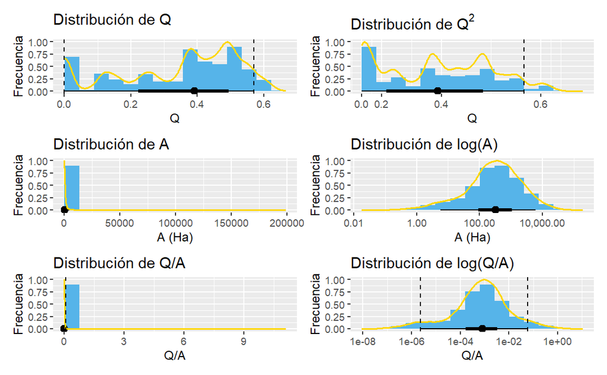

```r
# Distribución de Q
p_Q <- ggplot(ucs_rao_sf, aes(Q)) +
  ggdist::stat_histinterval(fill = "#56B4E9", color = "black", .width = c(0.5, 0.9)) +
  #"scaled" ajusta la altura a la del histograma
  geom_density(aes(y = after_stat(scaled)), color = "#FFD700", size = 0.8) +
  geom_vline(aes(xintercept = quantile(Q, 0.95, na.rm = TRUE)),
             linetype = "dashed") +
  geom_vline(aes(xintercept = quantile(Qdens, 0.05, na.rm = TRUE)),
             linetype = "dashed") +
  labs(title = "Distribución de Q", y = "Frecuencia", x = "Q")

#Distribución de Q con escala de potencia
p_Qpot <- ggplot(ucs_rao_sf, aes(x = Q)) +
  ggdist::stat_histinterval(fill = "#56B4E9", color = "black", .width = c(0.5, 0.9)) +
  #"scaled" ajusta la altura a la del histograma
  geom_density(aes(y = after_stat(scaled)), color = "#FFD700", size = 0.8) +
  geom_vline(aes(xintercept = quantile(Q, 0.95, na.rm = TRUE)),
             linetype = "dashed") +
  scale_x_continuous(trans = ggforce::power_trans(2),
                     name = "Q") +
  labs(title = expression("Distribución de " * Q^2), y = "Frecuencia")

#Dsistribución de áreas
p_A <- ggplot(ucs_rao_sf, aes(AREA_HA)) +
  ggdist::stat_histinterval(fill = "#56B4E9", color = "black", .width = c(0.5, 0.9)) +
  #"scaled" ajusta la altura a la del histograma
  geom_density(aes(y = after_stat(scaled)), color = "#FFD700", size = 0.8) +
  labs(title = "Distribución de A", y = "Frecuencia", x = "A (Ha)")

#Distribución de áreas con escala de log10
p_logA <- ggplot(ucs_rao_sf, aes(AREA_HA)) +
  ggdist::stat_histinterval(fill = "#56B4E9", color = "black" , .width = c(0.5, 0.9)) +
  #"scaled" ajusta la altura a la del histograma
  geom_density(aes(y = after_stat(scaled)), color = "#FFD700", size = 0.8) +
  scale_x_continuous(trans = "log10",
                     breaks = trans_breaks("log10", function(x) 10^x),
                     labels = label_comma()) +
  labs(title = "Distribución de log(A)", y = "Frecuencia", x = "A (Ha)")

#Distribución de Q/A
p_Qdens <- ggplot(ucs_rao_sf, aes(Qdens)) +
  ggdist::stat_histinterval(fill = "#56B4E9", color = "black" , .width = c(0.5, 0.9)) +
  #"scaled" ajusta la altura a la del histograma
  geom_density(aes(y = after_stat(scaled)), color = "#FFD700", size = 0.8) +
  geom_vline(aes(xintercept = quantile(Qdens, 0.95, na.rm = TRUE)),
             linetype = "dashed") +
  labs(title = "Distribución de Q/A", y = "Frecuencia", x = "Q/A")

#Distribución de Q/ A con esala log10
p_logQdens <- ggplot(ucs_rao_sf, aes(Qdens)) +
  ggdist::stat_histinterval(fill = "#56B4E9", color = "black" , .width = c(0.5, 0.9)) +
  #"scaled" ajusta la altura a la del histograma
  geom_density(aes(y = after_stat(scaled)), color = "#FFD700", size = 0.8) +
  geom_vline(aes(xintercept = quantile(Qdens, 0.95, na.rm = TRUE)),
             linetype = "dashed") +
  geom_vline(aes(xintercept = quantile(Qdens, 0.05, na.rm = TRUE)),
             linetype = "dashed") +
  scale_x_continuous(trans = "log10",
                     breaks = trans_breaks("log10", function(x) 10^x),
                     labels = label_scientific()) +
  labs(title = "Distribución de log(Q/A)", y = "Frecuencia", x = "Q/A")


# Exporta mosaico
p_mosaico_Qdens <-  p_Q + p_Qpot + p_A + p_logA + p_Qdens + p_logQdens + plot_layout(ncol = 2, widths = c(1, 1))

p_mosaico_Qdens

#guarda el último gráfico generado
ggsave(here("Figures","histogramas_Qdens.png"), width = 9, height = 9, dpi = 350)
```

### 3.2 Representación espacial de Q, A y Q/A

```r
#Mapa simple de Q
p_mapa_Q <- ggplot(ucs_rao_sf) +
  geom_sf(aes(fill = Q), color = NA) +
  scale_fill_gradientn(colours = pal, na.value = "white") +
  labs(title = "Mapa de Q", fill = "Q") +
  theme_minimal()

#Mapa  Q con escala potencia 2
p_mapa_Qpot <- ggplot(ucs_rao_sf) +
  geom_sf(aes(fill = Q), color = NA) +
  scale_fill_gradientn(
    colours = pal,
    na.value = "white",
    trans = ggforce::power_trans(2)  # This will apply Qdens^2 to the fill scale
  ) +
  labs(title = expression("Mapa en escala " * Q^2), fill = "Q") +
  theme_minimal()

#Mapa simple de áreas
#p_mapa_A <- ggplot(ucs_rao_sf) +
#  geom_sf(aes(fill = AREA_HA), color = NA) +
#  scale_fill_viridis_c() +
#  labs(title = "Mapa de A", fill = "A (Ha)") +
#  theme_minimal()

#Mapa de áreas con escala log10
#p_mapa_logA <- ggplot(ucs_rao_sf) +
#  geom_sf(aes(fill = AREA_HA), color = NA) +
#  scale_fill_viridis_c(trans = "log10") +
#  labs(title = "Mapa de log(A)", fill = "A (Ha)") +
#  theme_minimal()

#Mapa de Q/A simple
p_mapa_Qdens <- ggplot(ucs_rao_sf) +
  geom_sf(aes(fill = Qdens), color = NA) +
  scale_fill_gradientn(colours = pal, na.value = "white") +
  labs(title = "Mapa de Q/A", fill = "Q/A") +
  theme_minimal()

#Mapa de Q/A en escala log1'
p_mapa_logQdens <- ggplot(ucs_rao_sf) +
  geom_sf(aes(fill = Qdens), color = NA) +
  scale_fill_gradientn(
    colours = pal,
    na.value = "white",
    trans = "log10",
    breaks = scales::trans_breaks("log10", function(x) 10^x)
  ) +
  labs(title = "Mapa en escala log(Q/A)", fill = "Q/A") +
  theme_minimal()

p_mapas_Qdens <- p_mapa_Q + p_mapa_Qpot+ p_mapa_Qdens + p_mapa_logQdens + plot_layout(ncol = 2, widths = c(1, 1))

p_mapas_Qdens

#guarda el último gráfico generado
ggsave(here("Figures","mapas_Qdens.png"), width = 8, height = 9, dpi = 350)
```

[output not shown]

### 3.3 Cuantificar el efecto del área

A continuación se observa la distribución del área. Esto permite entender si requiere transformación para estudiar su relación con la diversidad.

Se observa la relación entre log(área) y pedodiversidad

```r
# Scatterplot Q vs área
p_puntos_Qdens <- ggplot(ucs_rao_sf, aes(x = AREA_HA, y = Q)) +
  geom_point(alpha = 0.5, color = "#56B4E9") +
  labs(title = "Relación entre Q y A", x = "A (Ha)", y = "Q")

# Scatterplot log(Q) vs log(A)
p_puntos_logQ_logA <- ggplot(ucs_rao_sf, aes(x = AREA_HA, y = Q)) +
  geom_point(alpha = 0.5, color = "#56B4E9") +
  scale_x_log10("log(A)") +
  scale_y_log10("log(Q)") +
  labs(title = "Relación entre log(Q) y log(A)", x = "log(A)", y = "log(Q)")


p_dispersion_Qdens <- p_puntos_Qdens + p_puntos_logQ_logA

p_dispersion_Qdens

#guarda el último gráfico generado
ggsave(here("Figures","dispersion_Qdens.png"), width = 8, height = 6, dpi = 350)
```

[output not shown]

Se calcula la correlación

```r
cor(ucs_rao_sf$Q, ucs_rao_sf$AREA_HA, use = "complete.obs", method = "spearman")
```

[output not shown]

### 3.4 Relación con otras variables

A contnuación se usan variables cualitativas presentes en los datos de CUS para explorar hipótesis sobre la relación con variables ambientales.

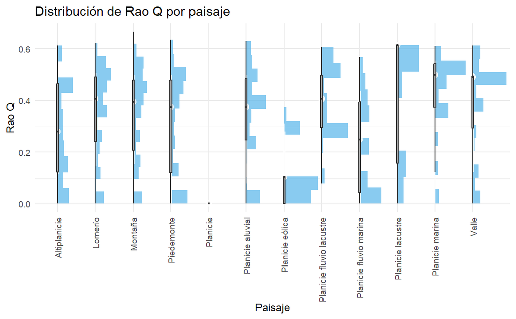

```r
ggplot(ucs_rao_sf |> tidyr::drop_na(), aes(y = Q, x = PAISAJE)) +
  stat_histinterval(binwidth = 0.02,
                   alpha = 0.7,
                   fill = "#56B4E9",
                   color = "white",
                   slab_color = NA) +
  geom_boxplot(width = 0.05, outlier.shape = NA, alpha = 0.7, fill = "gray50") +
  theme_minimal() +
  labs(title = "Distribución de Rao Q por paisaje",
       y = "Rao Q", x = "Paisaje") +
  theme(axis.text.x = element_text(angle = 90, hjust = 1, vjust = 0.5))
```

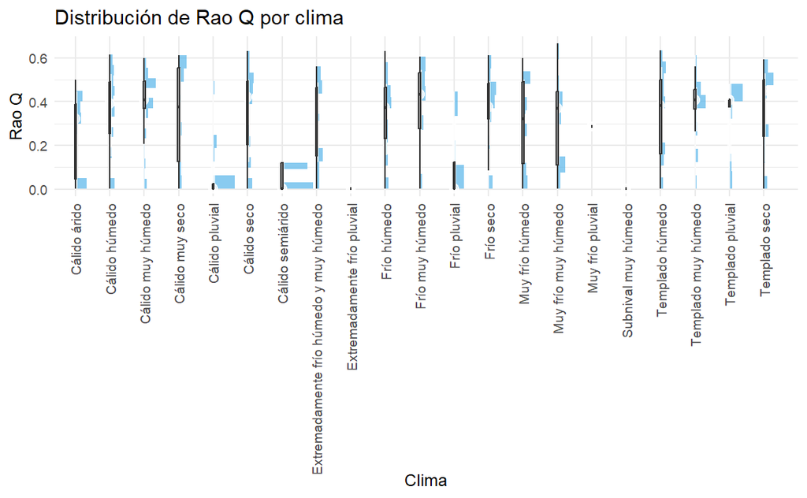

```r
ggplot(ucs_rao_sf |> tidyr::drop_na(), aes(y = Q, x = CLIMA_1)) +
  stat_histinterval(binwidth = 0.02,
                   alpha = 0.7,
                   fill = "#56B4E9",
                   color = "white",
                   slab_color = NA) +
  geom_boxplot(width = 0.05, outlier.shape = NA, alpha = 0.7, fill = "gray50") +
  theme_minimal() +
  labs(title = "Distribución de Rao Q por clima",
       y = "Rao Q", x = "Clima") +
  theme(axis.text.x = element_text(angle = 90, hjust = 1, vjust = 0.5))
```

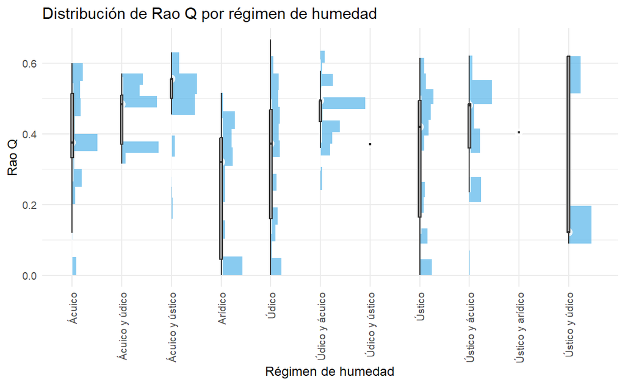

```r
ggplot(ucs_rao_sf |> tidyr::drop_na(), aes(y = Q, x = HUMEDAD)) +
  stat_histinterval(binwidth = 0.02,
                   alpha = 0.7,
                   fill = "#56B4E9",
                   color = "white",
                   slab_color = NA) +
  geom_boxplot(width = 0.05, outlier.shape = NA, alpha = 0.7, fill = "gray50") +
  theme_minimal() +
  labs(title = "Distribución de Rao Q por régimen de humedad",
       y = "Rao Q", x = "Régimen de humedad") +
  theme(axis.text.x = element_text(angle = 90, hjust = 1, vjust = 0.5))
```